# Red Wine Quality by Jeswin George

**Aim of this project** is to find out which chemical property influence the quality of red wines.

# Univariate Plots Section

Size of dataset

```
## [1] 1599   13
```

The dataset consists of 13 variables and 1599 observations.

Structure of dataset

```
## 'data.frame':    1599 obs. of  13 variables:
##  $ X                   : int  1 2 3 4 5 6 7 8 9 10 ...
##  $ fixed.acidity       : num  7.4 7.8 7.8 11.2 7.4 7.4 7.9 7.3 7.8 7.5 ...
##  $ volatile.acidity    : num  0.7 0.88 0.76 0.28 0.7 0.66 0.6 0.65 0.58 0.5 ...
##  $ citric.acid         : num  0 0 0.04 0.56 0 0 0.06 0 0.02 0.36 ...
##  $ residual.sugar      : num  1.9 2.6 2.3 1.9 1.9 1.8 1.6 1.2 2 6.1 ...
##  $ chlorides           : num  0.076 0.098 0.092 0.075 0.076 0.075 0.069 0.065 0.073 0.071 ...
##  $ free.sulfur.dioxide : num  11 25 15 17 11 13 15 15 9 17 ...
##  $ total.sulfur.dioxide: num  34 67 54 60 34 40 59 21 18 102 ...
##  $ density             : num  0.998 0.997 0.997 0.998 0.998 ...
##  $ pH                  : num  3.51 3.2 3.26 3.16 3.51 3.51 3.3 3.39 3.36 3.35 ...
##  $ sulphates           : num  0.56 0.68 0.65 0.58 0.56 0.56 0.46 0.47 0.57 0.8 ...
##  $ alcohol             : num  9.4 9.8 9.8 9.8 9.4 9.4 9.4 10 9.5 10.5 ...
##  $ quality             : int  5 5 5 6 5 5 5 7 7 5 ...
```

Converted the quality variable from type integer to type factor, as it denotes the ratings received by the wine.

Statistical summary of the given dataset

```
##        X          fixed.acidity   volatile.acidity  citric.acid
##  Min.   :   1.0   Min.   : 4.60   Min.   :0.1200   Min.   :0.000
##  1st Qu.: 400.5   1st Qu.: 7.10   1st Qu.:0.3900   1st Qu.:0.090
##  Median : 800.0   Median : 7.90   Median :0.5200   Median :0.260
##  Mean   : 800.0   Mean   : 8.32   Mean   :0.5278   Mean   :0.271
##  3rd Qu.:1199.5   3rd Qu.: 9.20   3rd Qu.:0.6400   3rd Qu.:0.420
##  Max.   :1599.0   Max.   :15.90   Max.   :1.5800   Max.   :1.000
##  residual.sugar     chlorides       free.sulfur.dioxide
##  Min.   : 0.900   Min.   :0.01200   Min.   : 1.00
##  1st Qu.: 1.900   1st Qu.:0.07000   1st Qu.: 7.00
##  Median : 2.200   Median :0.07900   Median :14.00
##  Mean   : 2.539   Mean   :0.08747   Mean   :15.87
##  3rd Qu.: 2.600   3rd Qu.:0.09000   3rd Qu.:21.00
##  Max.   :15.500   Max.   :0.61100   Max.   :72.00
##  total.sulfur.dioxide    density             pH          sulphates
##  Min.   :  6.00       Min.   :0.9901   Min.   :2.740   Min.   :0.3300
##  1st Qu.: 22.00       1st Qu.:0.9956   1st Qu.:3.210   1st Qu.:0.5500
##  Median : 38.00       Median :0.9968   Median :3.310   Median :0.6200
##  Mean   : 46.47       Mean   :0.9967   Mean   :3.311   Mean   :0.6581
##  3rd Qu.: 62.00       3rd Qu.:0.9978   3rd Qu.:3.400   3rd Qu.:0.7300
##  Max.   :289.00       Max.   :1.0037   Max.   :4.010   Max.   :2.0000
##     alcohol         quality
##  Min.   : 8.40   Min.   :3.000
##  1st Qu.: 9.50   1st Qu.:5.000
##  Median :10.20   Median :6.000
##  Mean   :10.42   Mean   :5.636
##  3rd Qu.:11.10   3rd Qu.:6.000
##  Max.   :14.90   Max.   :8.000
```

### Analyzing variable : Quality

To check out the most frequent quality of wines available in the dataset.

```r
table(wine_df$quality)
```

```
##
##   3   4   5   6   7   8
##  10  53 681 638 199  18
```

The above stats shows the available number of different qualities of red wine present in the given dataset. The best quality of red wine available in the given dataset is _**Quality 8** and it is totally 18 in number, Red wine with **Quality 7** is 199 in number.And the most avaliable qualities of red wine are **Quality 5** and **QUality 6** with 681 and 638 numbers respectively.

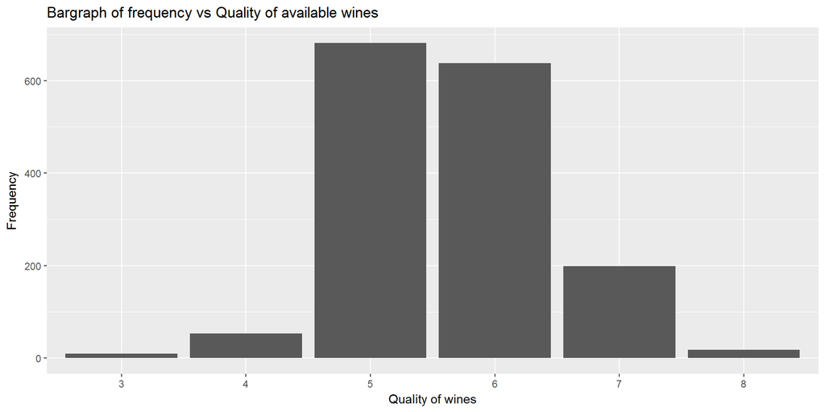

So from the above two analysis: it is observed that wines with quality rating 5 and 6 is the most available in the given dataset. Followed by quality 7 and quality 4. Quality 8 followed by quality 3 are the least available.

### Analyzing variable : fixed acidity

**Description of fixed acidity:** most acids involved with wine or fixed or nonvolatile (do not evaporate readily).

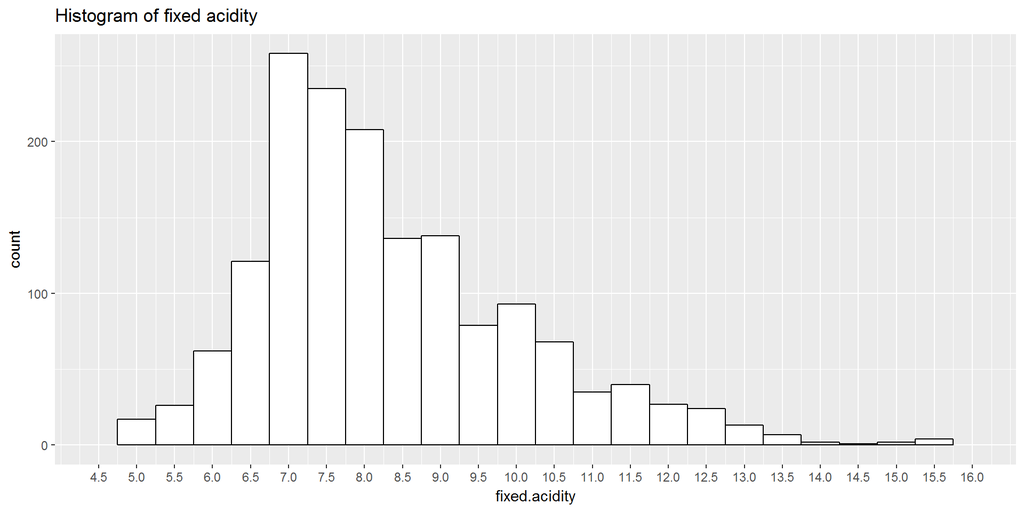

The above distribution is right-skewed and most of the wines in the given dataset have fixed acidity between 6.5 and 8 g/dm<sup>3</sup>.

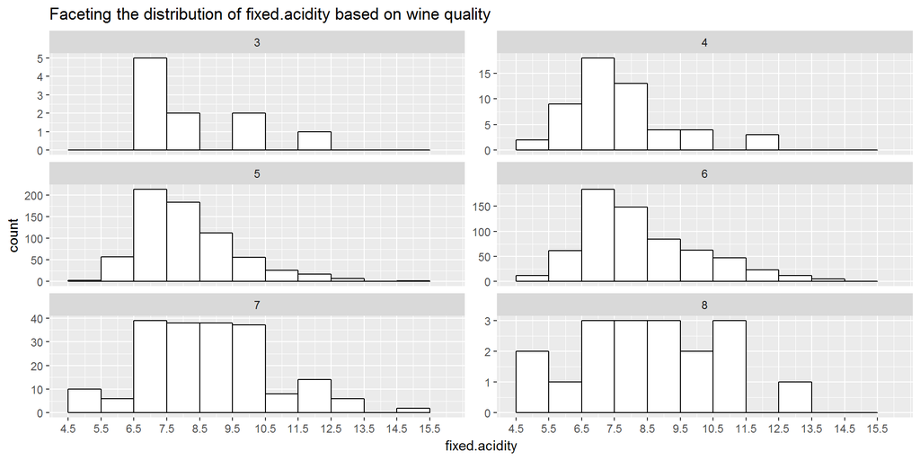

The above facetted graph, confirms the previous two analysis that the red wines with **Quality 5 and 6** are the most available in the dataset and their fixed acidity mostly ranges between 6.5 g/dm<sup>3</sup> and 8 g/dm<sup>3</sup> respectively. And the best two available qualities of wine **Quality 7 and 8** have a very low count and their value of fixed acidity usually varies between 6.5 and 11.5 g/dm<sup>3</sup>. Also **Quality 3 and 4** wines have value of fixed acidity varying between 6,5 and 8.5 g/dm<sup>3</sup>.

```
## wine_df$quality: 3
##    Min. 1st Qu.  Median    Mean 3rd Qu.    Max.
##   6.700   7.150   7.500   8.360   9.875  11.600
## --------------------------------------------------------
## wine_df$quality: 4
##    Min. 1st Qu.  Median    Mean 3rd Qu.    Max.
##   4.600   6.800   7.500   7.779   8.400  12.500
## --------------------------------------------------------
## wine_df$quality: 5
##    Min. 1st Qu.  Median    Mean 3rd Qu.    Max.
##   5.000   7.100   7.800   8.167   8.900  15.900
## --------------------------------------------------------
## wine_df$quality: 6
##    Min. 1st Qu.  Median    Mean 3rd Qu.    Max.
##   4.700   7.000   7.900   8.347   9.400  14.300
## --------------------------------------------------------
## wine_df$quality: 7
##    Min. 1st Qu.  Median    Mean 3rd Qu.    Max.
##   4.900   7.400   8.800   8.872  10.100  15.600
## --------------------------------------------------------
## wine_df$quality: 8
##    Min. 1st Qu.  Median    Mean 3rd Qu.    Max.
##   5.000   7.250   8.250   8.567  10.225  12.600
```

The above statistics show the summary of fixed acidity present in different qualities of red wine.

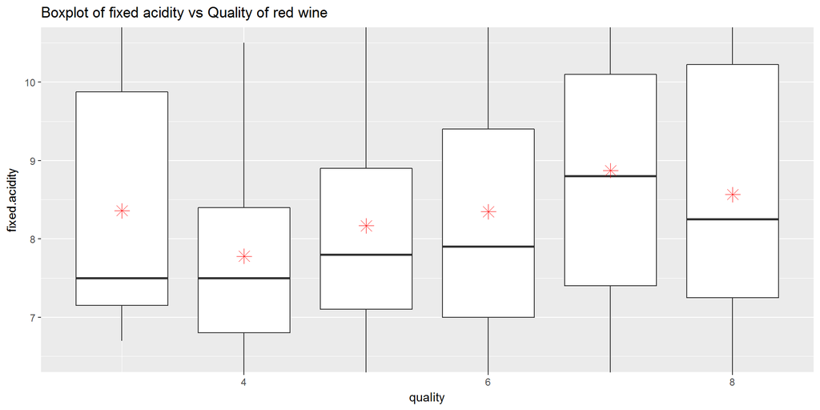

The **Quality 8** of red wine has median fixed acidity of 8.25 g/dm<sup>3</sup> and mean fixed acidity of 8.567 g/dm<sup>3</sup>. The **Quality 7** of red wine has median fixed acidity of 8.8 g/dm<sup>3</sup> and mean fixed acidity of 8.872 g/dm<sup>3</sup>.

The most available **Quality 5** of red wine has median fixed-acidity of 7.8 g/dm<sup>3</sup> and mean fixed-acidity of 8.167 g/dm<sup>3</sup>. And **Quality 6** of red wine  
has median fixed-acidity of 7.9 g/dm<sup>3</sup> and mean fixed-acidity of 8.347 g/dm<sup>3</sup>.

And the available poor qualities of red wine namely **Quality 3 and Quality 4** have median fixed acidity of 7.5 g/dm<sup>3</sup> each and their mean value of fixed acidity is 8.36 and 7.79 g/dm<sup>3</sup> respectively.

The red point shows the mean value of the fixed acidity.

So from the above anlaysis, fixed acidity volume does somewhat improve the quality of the condidered red wine.

### Analyzing variable : volatile acidity

**Description of volatile acidity:** the amount of acetic acid in wine, which at too high of levels can lead to an unpleasant, vinegar taste

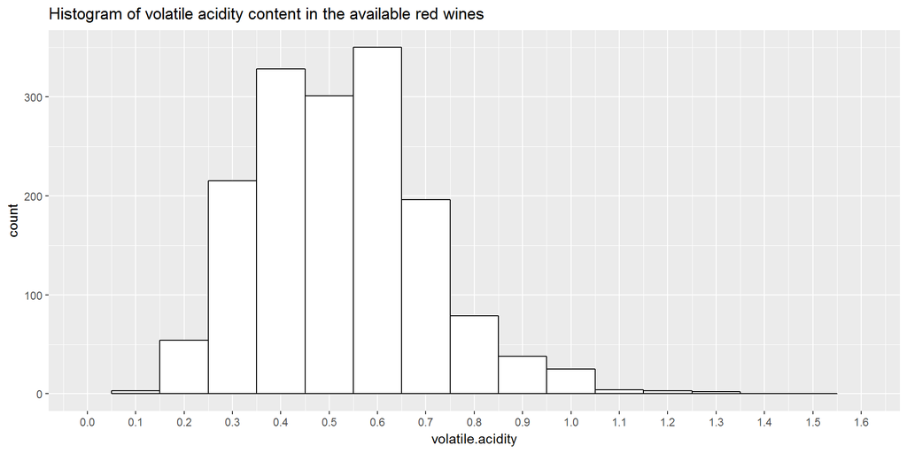

From the above histogram of volatile acidity - most of the wines have volatile acidity in the range of 0.3 to 0.7 g/dm<sup>3</sup>.

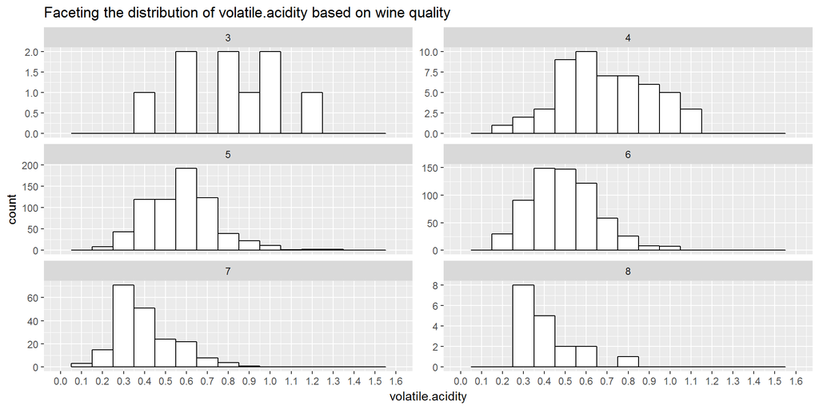

Most of the red wines with **Quality 8 and Quality 7** have volatile acidity usually ranging from 0.2 to 0.4 g/dm<sup>3</sup>. Also their distribution is right-skewed,so we can infer from this that good quality red wines have usually low values of volatile acidity.

Red wines of **Quality 6 and 5** are roughly normally distributed and their values usually range from 0.2 to 0.7 g/dm<sup>3</sup>.

Poor quality red wines of **Quality 3 and 4** have their values ranging from 0.4 to 1 g/dm<sup>3</sup>.

```
## wine_df$quality: 3
##    Min. 1st Qu.  Median    Mean 3rd Qu.    Max.
##  0.4400  0.6475  0.8450  0.8845  1.0100  1.5800
## --------------------------------------------------------
## wine_df$quality: 4
##    Min. 1st Qu.  Median    Mean 3rd Qu.    Max.
##   0.230   0.530   0.670   0.694   0.870   1.130
## --------------------------------------------------------
## wine_df$quality: 5
##    Min. 1st Qu.  Median    Mean 3rd Qu.    Max.
##   0.180   0.460   0.580   0.577   0.670   1.330
## --------------------------------------------------------
## wine_df$quality: 6
##    Min. 1st Qu.  Median    Mean 3rd Qu.    Max.
##  0.1600  0.3800  0.4900  0.4975  0.6000  1.0400
## --------------------------------------------------------
## wine_df$quality: 7
##    Min. 1st Qu.  Median    Mean 3rd Qu.    Max.
##  0.1200  0.3000  0.3700  0.4039  0.4850  0.9150
## --------------------------------------------------------
## wine_df$quality: 8
##    Min. 1st Qu.  Median    Mean 3rd Qu.    Max.
##  0.2600  0.3350  0.3700  0.4233  0.4725  0.8500
```

The above statistics show the summary of volatile acidity present in different qualities of red wine.

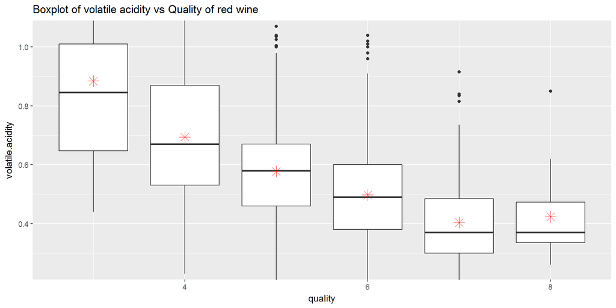

The above box plot shows that good quality red wines have lower amounts of volatile acids present in them.

### Analyzing variable : Citric Acid

**Description of Citric acid:** found in small quantities, citric acid can add ‘freshness’ and flavor to wines.

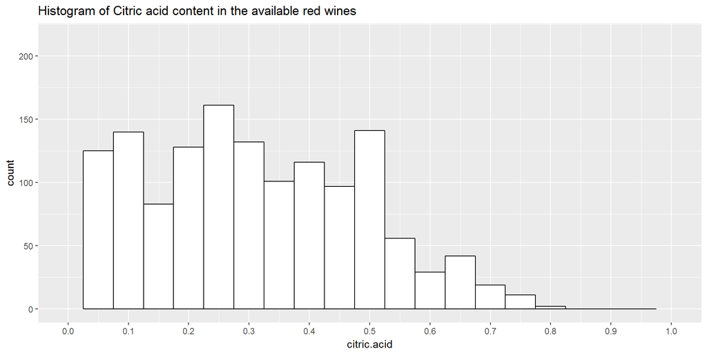

The above histogram on amount of citric acid in the red wines is right-skewed.

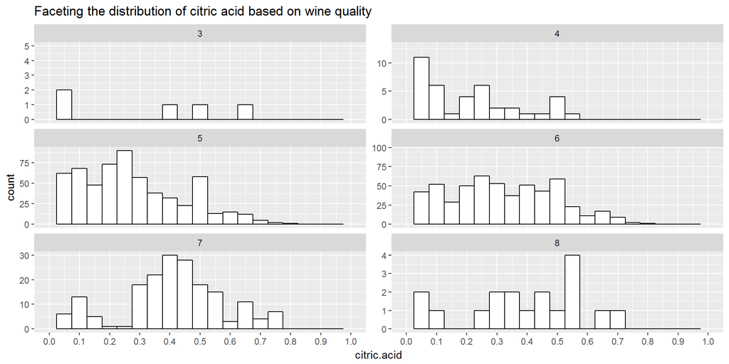

```
## wine_df$quality: 3
##    Min. 1st Qu.  Median    Mean 3rd Qu.    Max.
##  0.0000  0.0050  0.0350  0.1710  0.3275  0.6600
## --------------------------------------------------------
## wine_df$quality: 4
##    Min. 1st Qu.  Median    Mean 3rd Qu.    Max.
##  0.0000  0.0300  0.0900  0.1742  0.2700  1.0000
## --------------------------------------------------------
## wine_df$quality: 5
##    Min. 1st Qu.  Median    Mean 3rd Qu.    Max.
##  0.0000  0.0900  0.2300  0.2437  0.3600  0.7900
## --------------------------------------------------------
## wine_df$quality: 6
##    Min. 1st Qu.  Median    Mean 3rd Qu.    Max.
##  0.0000  0.0900  0.2600  0.2738  0.4300  0.7800
## --------------------------------------------------------
## wine_df$quality: 7
##    Min. 1st Qu.  Median    Mean 3rd Qu.    Max.
##  0.0000  0.3050  0.4000  0.3752  0.4900  0.7600
## --------------------------------------------------------
## wine_df$quality: 8
##    Min. 1st Qu.  Median    Mean 3rd Qu.    Max.
##  0.0300  0.3025  0.4200  0.3911  0.5300  0.7200
```

The above statistics show the summary of citric acid present in different qualities of red wine.

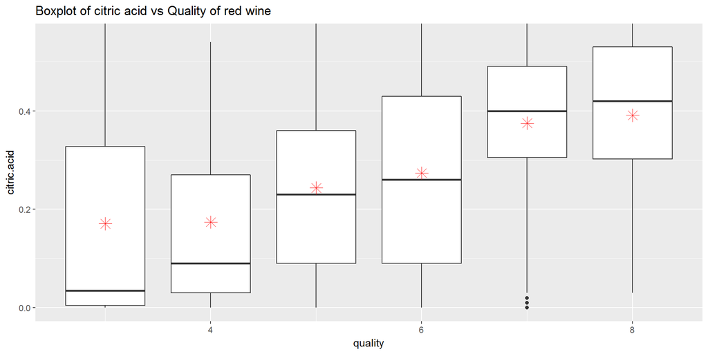

The above box plot shows that good quality red wines have higher amounts of citric acids present in them.

### Analyzing variable : residual sugar

**Description of residual sugar:** the amount of sugar remaining after fermentation stops, it is rare to find wines with less than 1 gram/liter and wines with greater than 45 grams/liter are considered sweet.

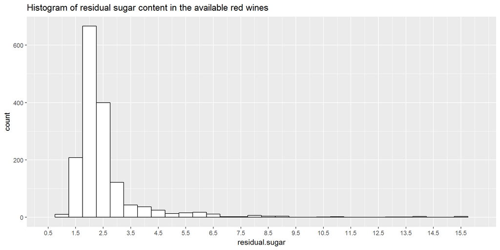

The distribution obtained above is right-skewed distribution. And most of the available red wines have residual sugar in the range of 1.5 to 2.5 grams/liter. Applying log scale to the residual sugar histogram.

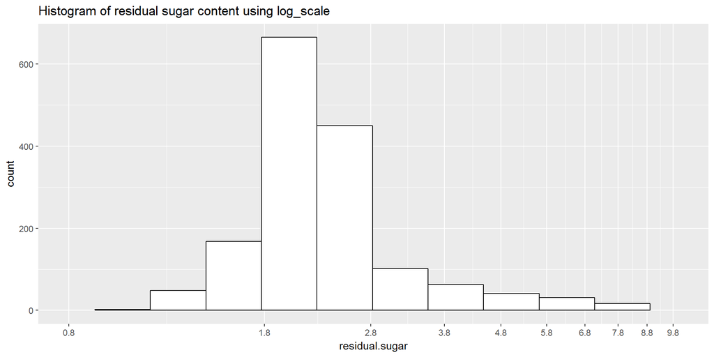

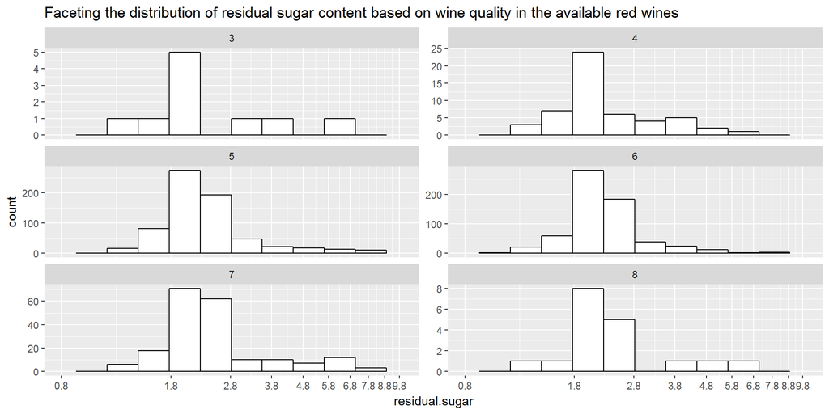

The above diagram shows that almost all qualities of red wines use residual sugar in amounts between 1.5 to 2.5 grams/liter. And scarcely do the values of the residual sugar level varies. So chances are that the presence of residual sugar must be almost fixed in all red wines.

```
## wine_df$quality: 3
##    Min. 1st Qu.  Median    Mean 3rd Qu.    Max.
##   1.200   1.875   2.100   2.635   3.100   5.700
## --------------------------------------------------------
## wine_df$quality: 4
##    Min. 1st Qu.  Median    Mean 3rd Qu.    Max.
##   1.300   1.900   2.100   2.694   2.800  12.900
## --------------------------------------------------------
## wine_df$quality: 5
##    Min. 1st Qu.  Median    Mean 3rd Qu.    Max.
##   1.200   1.900   2.200   2.529   2.600  15.500
## --------------------------------------------------------
## wine_df$quality: 6
##    Min. 1st Qu.  Median    Mean 3rd Qu.    Max.
##   0.900   1.900   2.200   2.477   2.500  15.400
## --------------------------------------------------------
## wine_df$quality: 7
##    Min. 1st Qu.  Median    Mean 3rd Qu.    Max.
##   1.200   2.000   2.300   2.721   2.750   8.900
## --------------------------------------------------------
## wine_df$quality: 8
##    Min. 1st Qu.  Median    Mean 3rd Qu.    Max.
##   1.400   1.800   2.100   2.578   2.600   6.400
```

The above statistics show the summary of residual sugar present in different qualities of red wine.

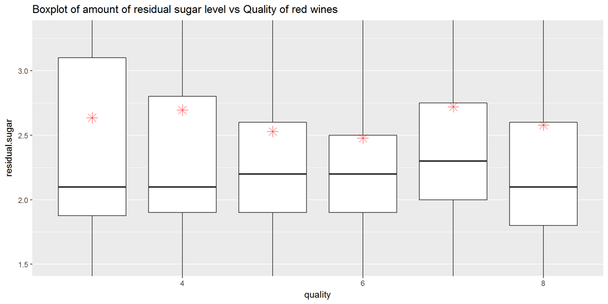

The above graph using boxplots and the statistical summary above that proves that in almost all qualities of red wines the median quantity of residual sugar ranges from 2.1 to 2.3 grams/liter. And the mean quantity of residual sugar is around 2.5 grams/liter. The red point shows the mean value of the residual sugar.

The huge variation between mean and median is due to the presence of outliers.

### Analyzing variable : chlorides

**Description of chlorides:** The amount of salt in the wine.

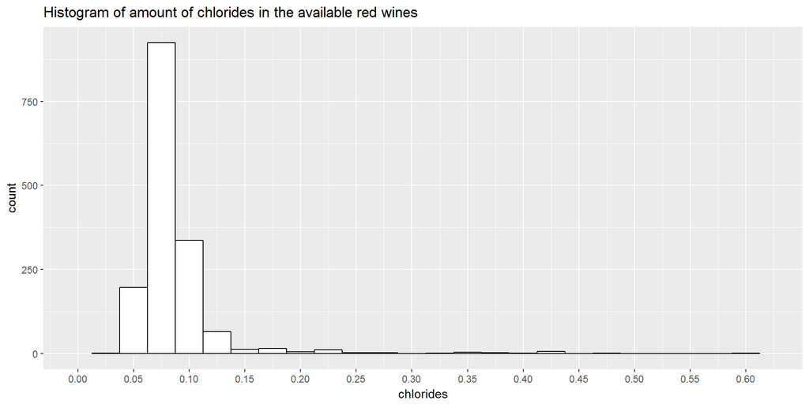

The above histogram has a right skewed distribution. And it can be concluded from the distribution that chlorides added to the red wines are in the range of 0.05 to 0.1 grams.

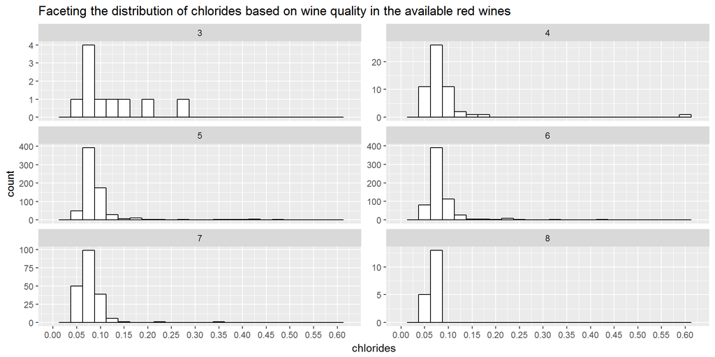

The above faceted graph shows almost all qualities of wine have their chlorides amount in the range of 0.05 to 1 grams. So it can be inferred that it is necessary to have chlorides in the abive mentioned range for the preapartaion of the above wine.

```
## wine_df$quality: 3
##    Min. 1st Qu.  Median    Mean 3rd Qu.    Max.
##  0.0610  0.0790  0.0905  0.1225  0.1430  0.2670
## --------------------------------------------------------
## wine_df$quality: 4
##    Min. 1st Qu.  Median    Mean 3rd Qu.    Max.
## 0.04500 0.06700 0.08000 0.09068 0.08900 0.61000
## --------------------------------------------------------
## wine_df$quality: 5
##    Min. 1st Qu.  Median    Mean 3rd Qu.    Max.
## 0.03900 0.07400 0.08100 0.09274 0.09400 0.61100
## --------------------------------------------------------
## wine_df$quality: 6
##    Min. 1st Qu.  Median    Mean 3rd Qu.    Max.
## 0.03400 0.06825 0.07800 0.08496 0.08800 0.41500
## --------------------------------------------------------
## wine_df$quality: 7
##    Min. 1st Qu.  Median    Mean 3rd Qu.    Max.
## 0.01200 0.06200 0.07300 0.07659 0.08700 0.35800
## --------------------------------------------------------
## wine_df$quality: 8
##    Min. 1st Qu.  Median    Mean 3rd Qu.    Max.
## 0.04400 0.06200 0.07050 0.06844 0.07550 0.08600
```

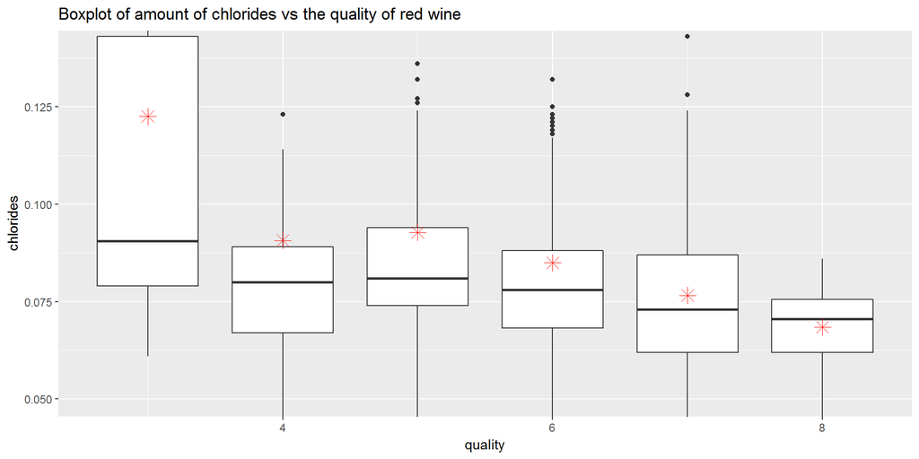

Using the boxplot and statistical summary it is seen that chlorides are used in small quanities of 0.05 to 0.15 grams. And the best available red wine of **quality 8** uses the least median amount of 0.0705 grams and as the quality of red wine decreases the chloride content increases along with it. The red point shows the mean value of the chlorides.

The huge difference between mean and median is due to the presence of these outliers.

### Analyzing variable : free.sulfur.dioxide

**Description of free.sulfur.dioxide:** The free form of SO2 exists in equilibrium between molecular SO2 (as a dissolved gas) and bisulfite ion; it prevents microbial growth and the oxidation of wine

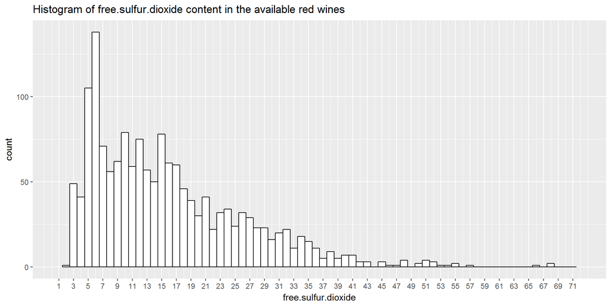

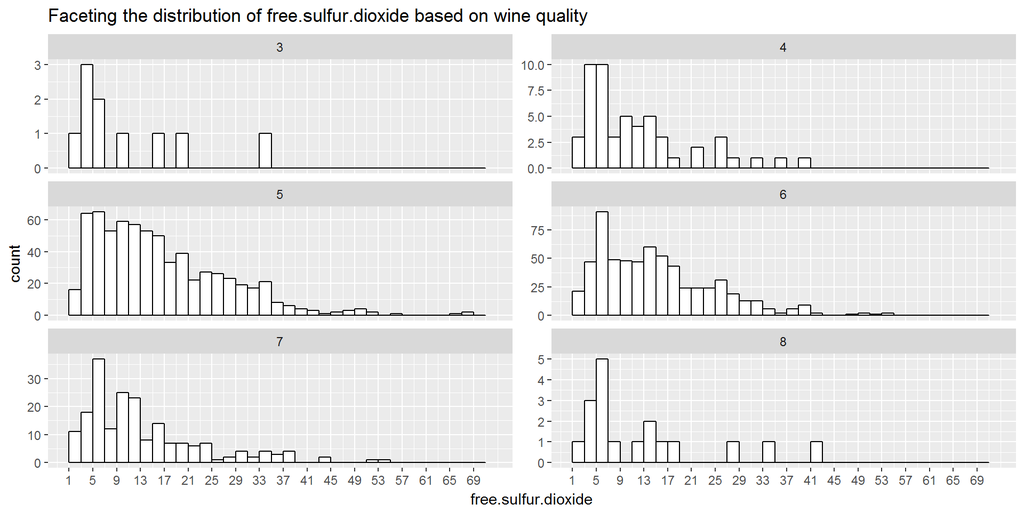

```
## wine_df$quality: 3
##    Min. 1st Qu.  Median    Mean 3rd Qu.    Max.
##     3.0     5.0     6.0    11.0    14.5    34.0
## --------------------------------------------------------
## wine_df$quality: 4
##    Min. 1st Qu.  Median    Mean 3rd Qu.    Max.
##    3.00    6.00   11.00   12.26   15.00   41.00
## --------------------------------------------------------
## wine_df$quality: 5
##    Min. 1st Qu.  Median    Mean 3rd Qu.    Max.
##    3.00    9.00   15.00   16.98   23.00   68.00
## --------------------------------------------------------
## wine_df$quality: 6
##    Min. 1st Qu.  Median    Mean 3rd Qu.    Max.
##    1.00    8.00   14.00   15.71   21.00   72.00
## --------------------------------------------------------
## wine_df$quality: 7
##    Min. 1st Qu.  Median    Mean 3rd Qu.    Max.
##    3.00    6.00   11.00   14.05   18.00   54.00
## --------------------------------------------------------
## wine_df$quality: 8
##    Min. 1st Qu.  Median    Mean 3rd Qu.    Max.
##    3.00    6.00    7.50   13.28   16.50   42.00
```

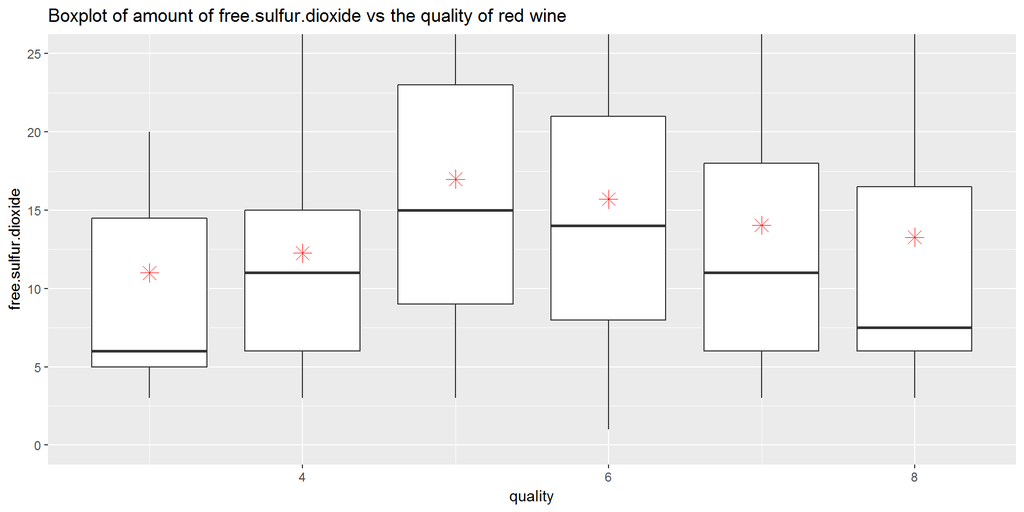

Using the boxplot and statistical summary it can be inferred that even though the presence of free sulfur dioxide is essential in red quality wines to prevent the growth of microbes, its amount in the wine does not have much affect on its quality. The red point shows the mean value of the free sulfur dioxide.

### Analyzing variable : total.sulfur.dioxide

**Description of total.sulfur.dioxide:** Amount of free and bound forms of S0<sup>2</sup> in low concentrations. S0<sup>2</sup> is mostly undetectable in wine but at free S0<sup>2</sup> concentrations over 50 ppm, S0<sup>2</sup> becomes evident in the nose and taste of wine.

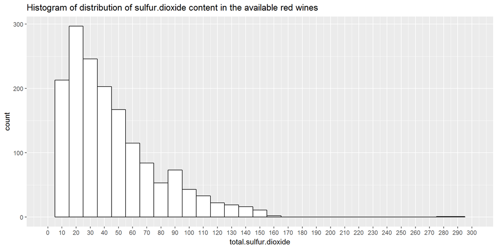

The given histogram is right skewed in nature. And most of the available red quality wines have total sulfur dioxide of amount about 20 to 30 ppm.

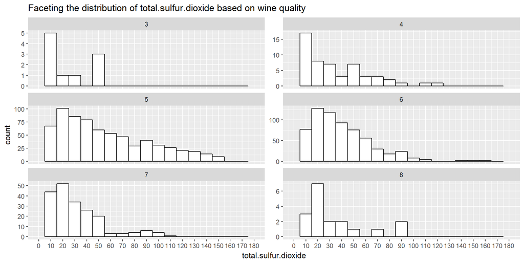

```
## wine_df$quality: 3
##    Min. 1st Qu.  Median    Mean 3rd Qu.    Max.
##     9.0    12.5    15.0    24.9    42.5    49.0
## --------------------------------------------------------
## wine_df$quality: 4
##    Min. 1st Qu.  Median    Mean 3rd Qu.    Max.
##    7.00   14.00   26.00   36.25   49.00  119.00
## --------------------------------------------------------
## wine_df$quality: 5
##    Min. 1st Qu.  Median    Mean 3rd Qu.    Max.
##    6.00   26.00   47.00   56.51   84.00  155.00
## --------------------------------------------------------
## wine_df$quality: 6
##    Min. 1st Qu.  Median    Mean 3rd Qu.    Max.
##    6.00   23.00   35.00   40.87   54.00  165.00
## --------------------------------------------------------
## wine_df$quality: 7
##    Min. 1st Qu.  Median    Mean 3rd Qu.    Max.
##    7.00   17.50   27.00   35.02   43.00  289.00
## --------------------------------------------------------
## wine_df$quality: 8
##    Min. 1st Qu.  Median    Mean 3rd Qu.    Max.
##   12.00   16.00   21.50   33.44   43.00   88.00
```

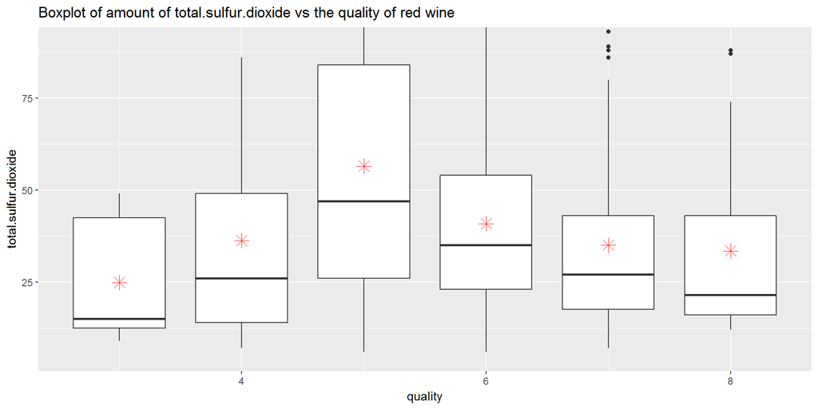

From the statistical summary and boxplot it is seen that only **quality 5** red wines have the highest content of total sulfur dioxide with median value of 47 ppm and mean value of 56.51 ppm. Also the best quality of available red wine which is **quality 8** have low median content of total sulfur dioxide with 21.5 ppm and low mean content of total sulfur dioxide 33.44. And **quality 3** which has low median content of 15 ppm and mean content of 24.9 ppm. So based on the amount of total sulfur dioxide available in each quality of wine we cannot decide whether quality of red wine is good or not. The red point shows the mean value of the total sulfur dioxide.

### Analyzing variable : density

**Description of density:** the density of water is close to that of water depending on the percent alcohol and sugar content.

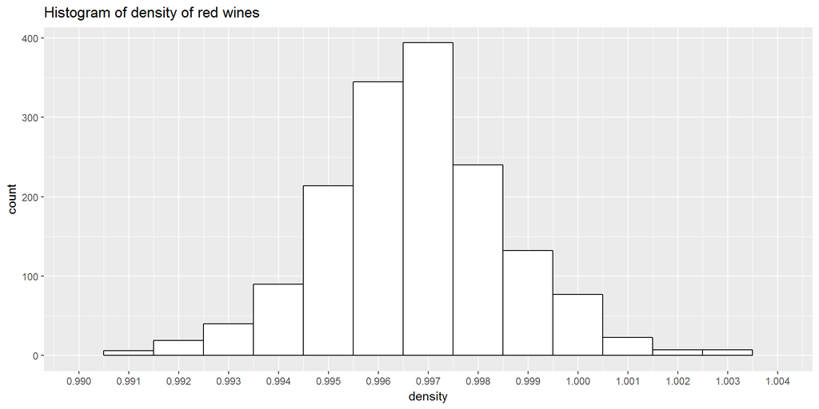

The above histogram on density of red wines has a normal distribution and most of the available red wines have a density in the range of 0.995 to 0.997.

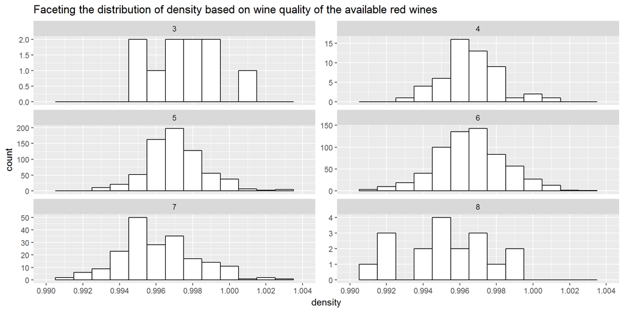

The faceted distribution shows that almost all qaulity of red wines have a normal distribution with their mean value of density concentrated around the 0.994 to 0.996 region of density for **quality 7 and quality 8** red wines. And the other lower quality wines had their majority of the density values ranging from 0.995 to 0.997.

```
## wine_df$quality: 3
##    Min. 1st Qu.  Median    Mean 3rd Qu.    Max.
##  0.9947  0.9961  0.9976  0.9975  0.9988  1.0008
## --------------------------------------------------------
## wine_df$quality: 4
##    Min. 1st Qu.  Median    Mean 3rd Qu.    Max.
##  0.9934  0.9957  0.9965  0.9965  0.9974  1.0010
## --------------------------------------------------------
## wine_df$quality: 5
##    Min. 1st Qu.  Median    Mean 3rd Qu.    Max.
##  0.9926  0.9962  0.9970  0.9971  0.9979  1.0031
## --------------------------------------------------------
## wine_df$quality: 6
##    Min. 1st Qu.  Median    Mean 3rd Qu.    Max.
##  0.9901  0.9954  0.9966  0.9966  0.9979  1.0037
## --------------------------------------------------------
## wine_df$quality: 7
##    Min. 1st Qu.  Median    Mean 3rd Qu.    Max.
##  0.9906  0.9948  0.9958  0.9961  0.9974  1.0032
## --------------------------------------------------------
## wine_df$quality: 8
##    Min. 1st Qu.  Median    Mean 3rd Qu.    Max.
##  0.9908  0.9942  0.9949  0.9952  0.9972  0.9988
```

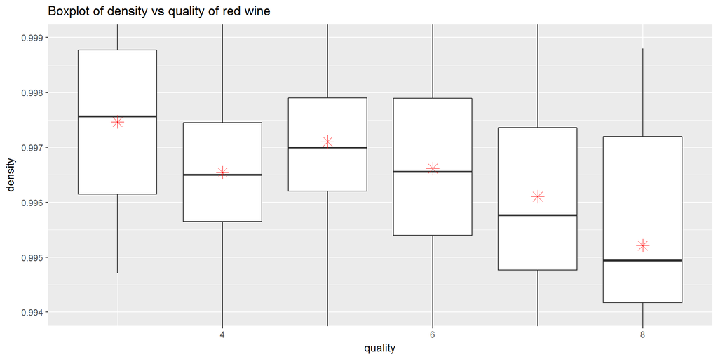

From the statistical summary and boxplot it can be seen that good quality red wines having **quality 8 and 7** have a low median value of density 0.9949 and 0.9958 respectively, and mean density value of 0.9952 and 0.9961. For other lower qualities of wine such as **quality 3** has median density value of 0.9976 and mean density value of 0.9975. So it can be said that lower density of red wines denotes better quality. The red point shows the mean value of the density.

### Analyzing variable : pH

**Description of pH:** describes how acidic or basic a wine is on a scale from 0 (very acidic) to 14 (very basic); most wines are between 3-4 on the pH scale.

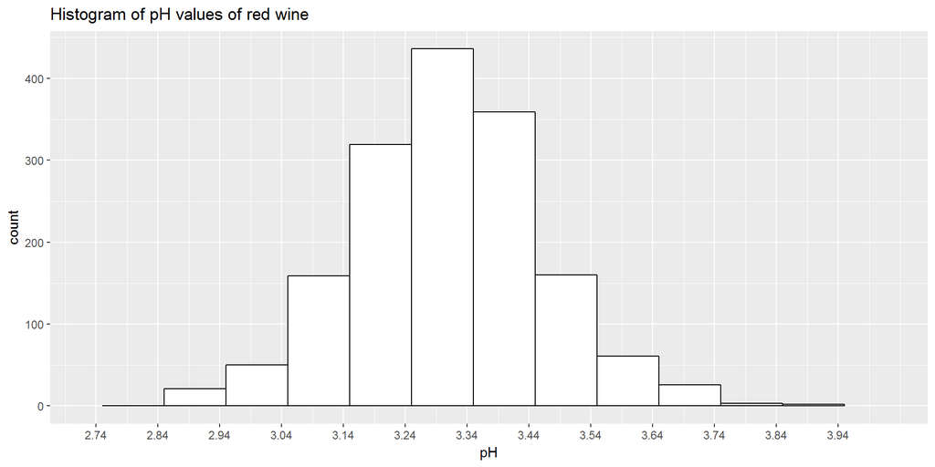

The above histogram has a normal distribution and most of the red wines have pH values in the range of 3.14 to 3.44.

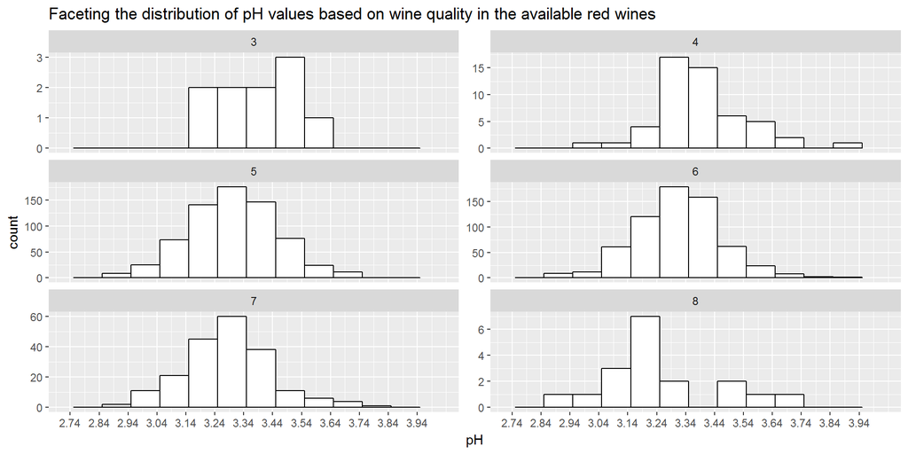

From the above faceted graph it can be seen that **quality 5 to 8** have normal distribution and their values range from 3.14 to 3.44. The graph of distribution of pH values for different qualities of red wine are not much helpful in finding how pH values affect quality.

```
## wine_df$quality: 3
##    Min. 1st Qu.  Median    Mean 3rd Qu.    Max.
##   3.160   3.312   3.390   3.398   3.495   3.630
## --------------------------------------------------------
## wine_df$quality: 4
##    Min. 1st Qu.  Median    Mean 3rd Qu.    Max.
##   2.740   3.300   3.370   3.382   3.500   3.900
## --------------------------------------------------------
## wine_df$quality: 5
##    Min. 1st Qu.  Median    Mean 3rd Qu.    Max.
##   2.880   3.200   3.300   3.305   3.400   3.740
## --------------------------------------------------------
## wine_df$quality: 6
##    Min. 1st Qu.  Median    Mean 3rd Qu.    Max.
##   2.860   3.220   3.320   3.318   3.410   4.010
## --------------------------------------------------------
## wine_df$quality: 7
##    Min. 1st Qu.  Median    Mean 3rd Qu.    Max.
##   2.920   3.200   3.280   3.291   3.380   3.780
## --------------------------------------------------------
## wine_df$quality: 8
##    Min. 1st Qu.  Median    Mean 3rd Qu.    Max.
##   2.880   3.163   3.230   3.267   3.350   3.720
```

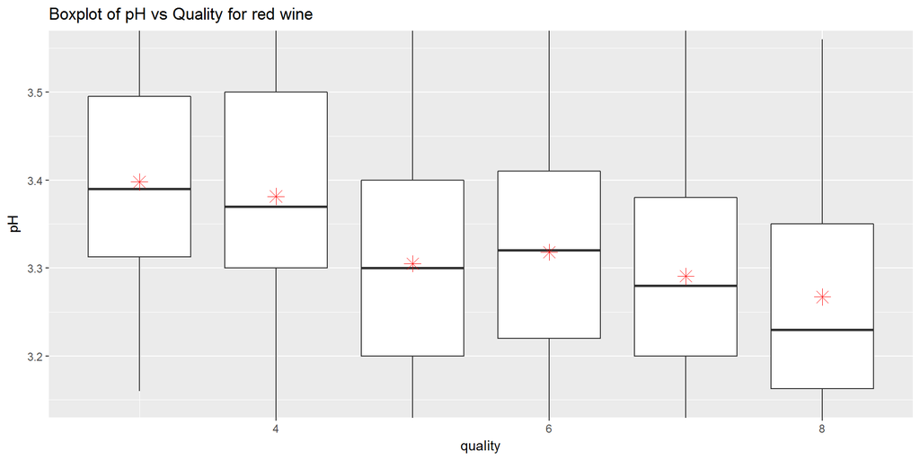

### Analyzing variable : sulphates

**Description of sulphates:** a wine additive which can contribute to sulfur dioxide gas (S02) levels, wich acts as an antimicrobial and antioxidant.

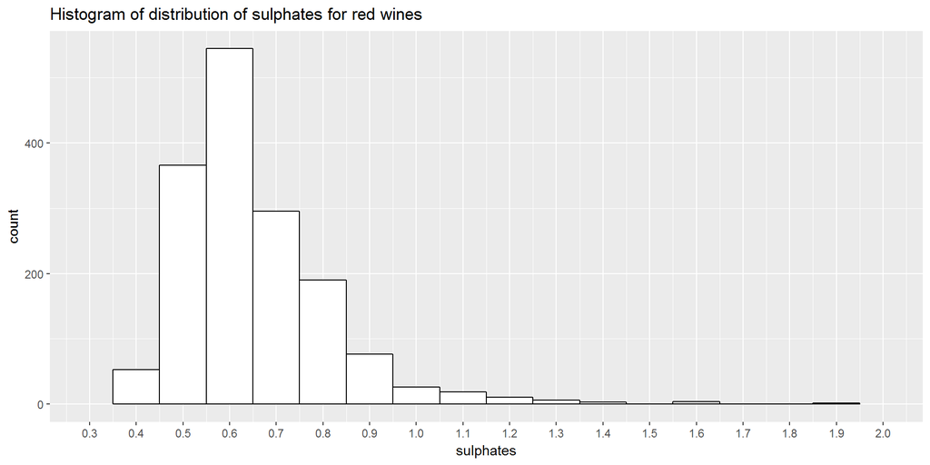

The distribution of sulphates in red wine has a right-skewed distribution with the mode value of sulphates lying in the range from 0.5 to 0.6.

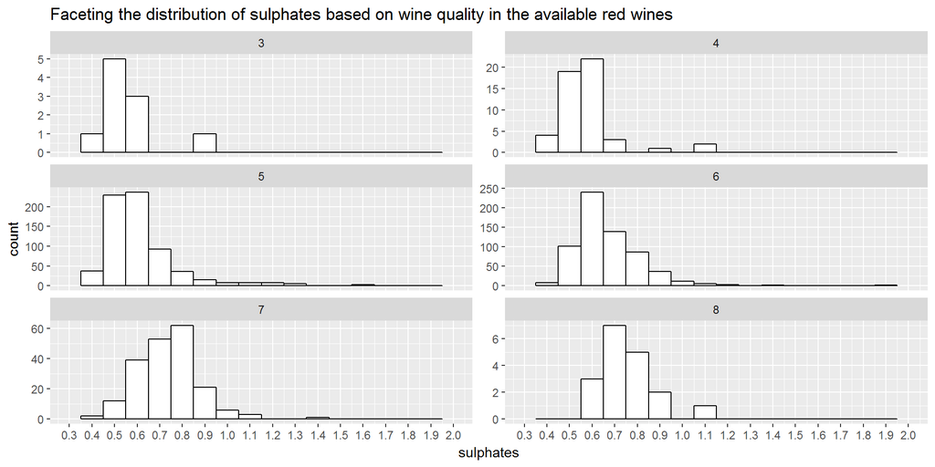

From the faceted distribution of sulphates considering quality as the categorical variable it is seen that that the amount of sulphates in higher quality of wines such as **quality 8 and 7** have slightly higher higher amount of sulphates than those ranging from quality 3 to quality 6.

```
## wine_df$quality: 3
##    Min. 1st Qu.  Median    Mean 3rd Qu.    Max.
##  0.4000  0.5125  0.5450  0.5700  0.6150  0.8600
## --------------------------------------------------------
## wine_df$quality: 4
##    Min. 1st Qu.  Median    Mean 3rd Qu.    Max.
##  0.3300  0.4900  0.5600  0.5964  0.6000  2.0000
## --------------------------------------------------------
## wine_df$quality: 5
##    Min. 1st Qu.  Median    Mean 3rd Qu.    Max.
##   0.370   0.530   0.580   0.621   0.660   1.980
## --------------------------------------------------------
## wine_df$quality: 6
##    Min. 1st Qu.  Median    Mean 3rd Qu.    Max.
##  0.4000  0.5800  0.6400  0.6753  0.7500  1.9500
## --------------------------------------------------------
## wine_df$quality: 7
##    Min. 1st Qu.  Median    Mean 3rd Qu.    Max.
##  0.3900  0.6500  0.7400  0.7413  0.8300  1.3600
## --------------------------------------------------------
## wine_df$quality: 8
##    Min. 1st Qu.  Median    Mean 3rd Qu.    Max.
##  0.6300  0.6900  0.7400  0.7678  0.8200  1.1000
```

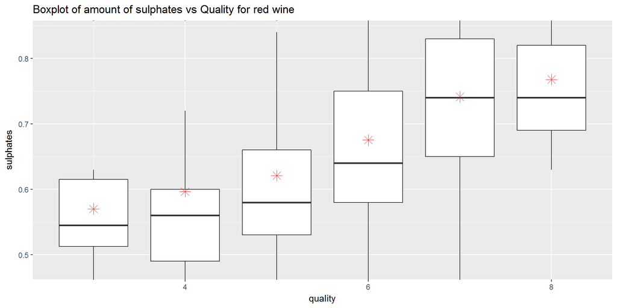

From the statistical summary and boxplot of sulphates vs the quality of red wines it is observed that better quality red wines such as **quality 8 and 7** have higher median amd mean value of sulphates as compared to that of other lower quality red wines. The red point shows the mean value of the sulphates.